# LPJ-GUESS patch output - A user’s guide

### LPJ-GUESS

To understand the data, it’s helpful to first have a look at LPJ-GUESS and its structure.

We force the model by gridded climate data. Each **gridcell** of climate input or model output is identified by the Latitude and Longitude of its centroid. While climate data is daily, most model output is yearly.

Within each gridcell the model simulates independent **patches** of vegetation. These evolve under the same climate but differ due to stochasticity. In this study 25 patches where simulated. **Therefore each patch in the simulation can be uniquely identified by its Latitude, Longitude and Patch ID!**

Within each patch, multiple vegetation types exist that we call **PFTs** (plant function types). The PFTs we consider in this study are:

- **BNE**: Boreal needleeleaf evergreen trees
- **IBS**: Pioneering broadleafed summergreen trees
- **TeBS**: Temperate broadleafed summergreen trees
- **otherC**: all coniferious PFTs, already aggregated
- **Tundra**: various grass and shrub PFTs, already aggegated

**Disturbances** occur on the patch level with a given probability.

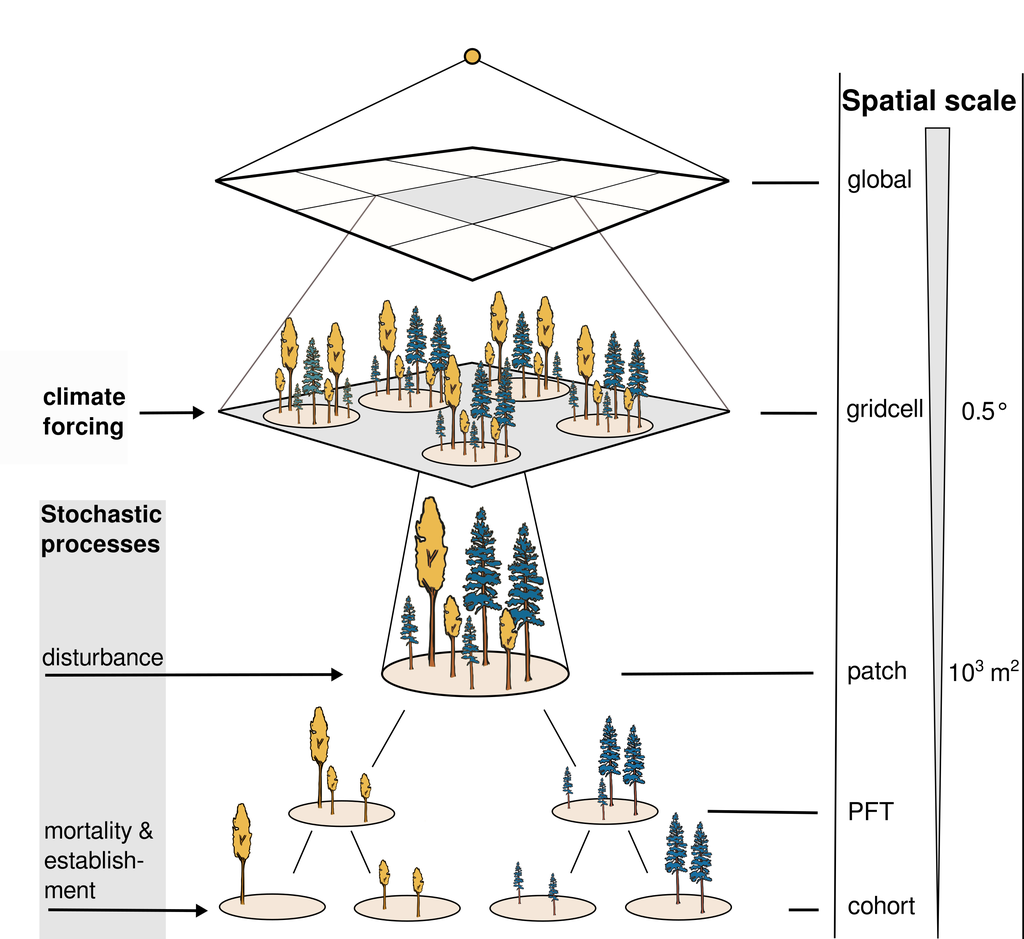

### Columns of datasets

- `Year`: Simulation year
- `Lon`: Longitude of gridcell
- `Lat`: Latitude of gridcell
- `PID`: Patch ID
- `PFT`: Plant functional type
- `dhist`: Disturbance history, 1 if disturbances occurred in a year, 0 otherwise.
- `ndist`: Number of disturbances in that patch since the start of the simulation.
- `age`: Patch age, i.e. time since last disturbance
- `cmass`: Aboveground carbon in kg/m²
- `lai`: Leaf area index, leaf area in m²/m²
- `dens`: Tree density
- `exp_est`: The expected value of newly established individuals per `PFT` (establishment is realized as a Poisson process)
- `fpc`: Plant fractional cover, the percentage of an area covered by a certain PFT. If $\sum$FPC over all PFTs < 1, $FPC_{soil} = 1 - \sum_i^{PFTs} FPC_{i}$.